```python
import pandas as pd
import numpy as np
sns.set(style="whitegrid", color_codes=True)
import matplotlib.pyplot as plt
```

**`A ideia desta análise é mostra os Países que mais consomem bebidas alcólicas e o continente com mais consulmo do mesmo.`** **`Seguindo os países de cada continete`**

# Lendo o dataSet Drinks.csv

```python
df= pd.read_csv('./drinks.csv')
```

## Vamos agora entrar na limpeza dos dados.

```python
df.isnull().sum()
```

```
country                          0
beer_servings                    0
spirit_servings                  0
wine_servings                    0
total_litres_of_pure_alcohol     0
continent                       23
dtype: int64
```

#### Temos 23 contines nulos. Iremos tratá-losa mais para frente.

## Tratamento de Anomálias.

```
AxesSubplot(0.125,0.125;0.775x0.755)
```

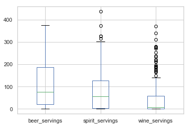

```python
%matplotlib inline
print(df.boxplot(column=['beer_servings','spirit_servings','wine_servings']))
#sns.boxplot(data=[df['spirit_servings']]);
```

Resumo dos boxplot nas colunas spirit_servings , wine_servings temos concentrações de valores acima da média . Ou seja temos valores fora do padrão que podem interferir em nossa análise futuralmente. Sendo que na coluna wine_servings temos uma concentração maior desses valores. Iremos buscar esses valores a cima da média logo abaixo.

Vamos calcular desvio padrão

```python
desvio = np.std(df, axis=0)
```

**fronteira de valor acima da média em duas vezes o dsvio padrão**

```python
media =np.mean(df, axis=0)
```

```python
array1 = np.array(df['spirit_servings'])
array2 = np.array(df['wine_servings'])
```

```python
spirit_servings=[ x for x in array1 if (x > media.spirit_servings + 2 * desvio.spirit_servings)]
wine_servings= [ y for y in array2 if (y > media.wine_servings + 2 * desvio.wine_servings)]
```

**Total e listagem de valores anomalos detectados para o atributo spirit_servings**

```python
print("Total:{}, Listagem:{}".format(len(spirit_servings),spirit_servings))
```

```
Total:9, Listagem:[373, 286, 438, 302, 326, 326, 315, 293, 258]
```

**Total e listagem de valores anomalos detectados para o atributo wine_servings**

```python
print("Total:{}, Listagem:{}".format(len(wine_servings),wine_servings))
```

```
Total:15, Listagem:[312, 221, 212, 212, 254, 278, 233, 370, 218, 237, 271, 339, 276, 280, 220]
```

**Plotagem de valores anomalos detectados para o atributo spirit_servings**

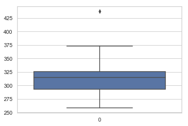

```python
sns.boxplot(data=spirit_servings);
```

**Plotagem de valores anomalos detectados para o atributo wine_servings**

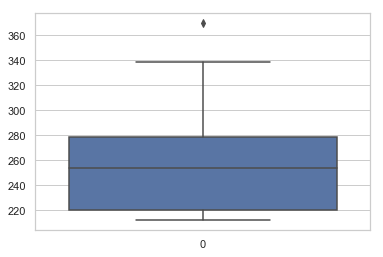

```python
sns.boxplot(data=wine_servings);
```

**removendo os valores muito acima da média spirit_servings Listagem:[373, 286, 438, 302, 326, 326, 315, 293, 258]**

```python
spirit_servings=spirit_servings=[ x for x in array1 if (x < media.spirit_servings + 2 * desvio.spirit_servings)]
```

```python
print("Total:{}, Listagem:{}".format(len(spirit_servings),spirit_servings))
```

```
Total:184, Listagem:[0, 132, 0, 138, 57, 128, 25, 179, 72, 75, 46, 176, 63, 0, 173, 84, 114, 4, 0, 41, 173, 35, 145, 2, 252, 7, 0, 1, 56, 65, 1, 122, 2, 1, 124, 192, 76, 3, 1, 254, 87, 87, 137, 154, 170, 0, 3, 81, 44, 147, 74, 4, 69, 0, 0, 194, 3, 35, 133, 151, 98, 0, 100, 117, 3, 112, 69, 0, 31, 98…
```

**removendo os valores muito acima da média wine_servings Listagem:[312, 221, 212, 212, 254, 278, 233, 370, 218, 237, 271, 339, 276, 280, 220]**

```python
wine_servings=[ y for y in array2 if (y <  media.wine_servings + 2 * desvio.wine_servings)]
```

```python
print("Total:{}, Listagem:{}".format(len(wine_servings),wine_servings))
```

```
Total:178, Listagem:[0, 54, 14, 45, 45, 11, 191, 5, 51, 7, 0, 36, 42, 8, 13, 0, 8, 8, 35, 16, 1, 94, 7, 0, 7, 16, 1, 4, 100, 1, 1, 172, 8, 3, 1, 9, 74, 11, 5, 113, 134, 0, 1, 3, 26, 9, 3, 1, 2, 0, 59, 0, 1, 97, 59, 1, 149, 175, 10, 28, 2, 2, 21, 1, 1, 2, 185, 78, 0, 0, 0, 0, 165, 9, 9, 16, 1, 12, 2,…
```

Criando Series wine_servings e spirit_servings para atribuir no dataFrame

```python
series_wine_servings =pd.Series(wine_servings)
series_spirit_servings= pd.Series(spirit_servings)
```

**Como no nosso dataframe temos as colunas com as anolalias, iremos dropar essas colunas e criala-las novamente com a nossa serie. Aproveitaremos tambem e deletaremos a coluna total_litres_of_pure_alcohol já que fizemos operações de limpesa em nossas coluna, esta coluna de total precisará se recalculada.**

```python
df.drop(['spirit_servings','wine_servings','total_litres_of_pure_alcohol'], axis=1 , inplace=True)
```

```python
df.columns
```

```
Index(['country', 'beer_servings', 'continent'], dtype='object')
```

```python
df['wine_servings']=series_wine_servings
df['spirit_servings']=series_spirit_servings
```

```python
df.isnull().sum()
```

```
country             0
beer_servings       0
continent          23
wine_servings      15
spirit_servings     9
dtype: int64
```

Notamos que ao criar nossas colunas , surgiram novo valores faltantes. Isso se deve ao fato que nossa series_wine_servings e series_spirit_servings tinham menos linhas que nosso dataFrame. Então ao criar nossa coluna. o pandas completa com null para igualar ao dataframe

```python
df.dropna(inplace=True)
```

```python
df.isnull().sum()
```

```
country            0
beer_servings      0
continent          0
wine_servings      0
spirit_servings    0
dtype: int64
```

```python
df['total_drinks']= df['beer_servings']+df['wine_servings']+df['spirit_servings']
```

**Agora com o nosso dataFrame limpo, podemos dar um save e partir para anáise exploratória.**

```python
df.to_csv('bebidas.csv')
```

# Análise exploratória

```python
# Lendo base recém salva.
bebidas= pd.read_csv('bebidas.csv')
```

**Listando novamente as questões a serem respondias:**

- Os Países que mais consomen bebidas;
- O continente com mais consulmo de bebidas;
- O menor consumo e maior consumo por continente;

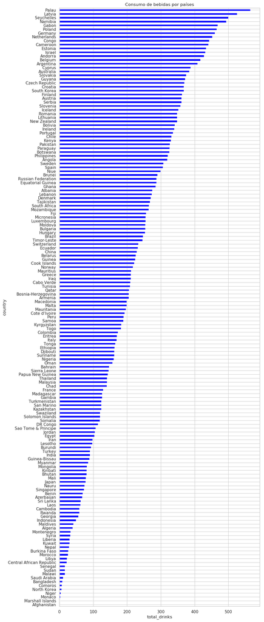

```python
ax = bebidas.groupby('country')['total_drinks'].sum().sort_values().plot(kind="barh", color="blue", figsize=(10,30))
plt.xlabel("total_drinks")
plt.ylabel("country")
plt.title("Consumo de bebidas por países")
plt.show()
```

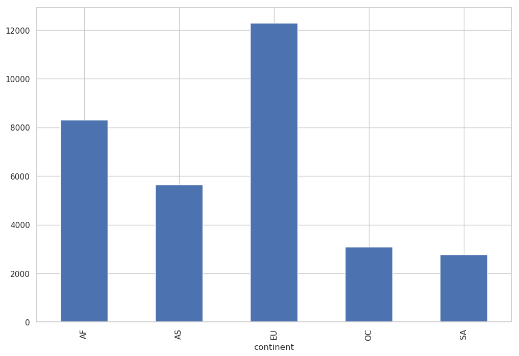

```python
bebidas.groupby('continent')['total_drinks'].sum().plot(kind='bar')
```

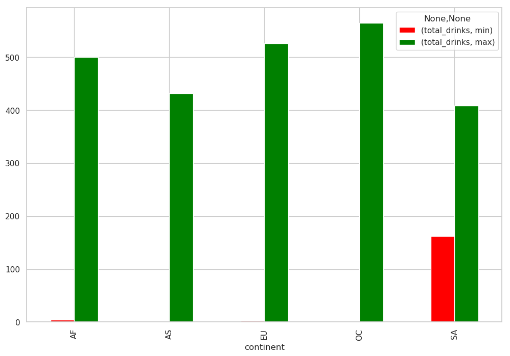

```python
bebidas.groupby("continent").agg({"total_drinks":['min','max']}).plot(kind="bar", color=["red","green"])
```